# 102B HW4

Yiran Liu

5/25/2021

**1**

**a**

pseudo-code:

Input: # g: A cost function: # alpha choice: If it is “diminishing”, execute random search with diminishing # steplength. If it is a numerical value, let it be the fixed steplength (default: 1). # max its: The maximum number of iteration (default: 100) # w0: An initial point # tol: The tolerance for the stop criteria (default: 10−5) # # output: list object # weight history: A n × 2 matrix for weight history # cost history: A vector for corresponding cost function history

w1<- w0[1] w2<- w0[2] weight_history_w1<- w1 weight_history_w2<- w2 cost_history<- g(w1,w2) current_value <- g(w1, w2)

For each iteration, we want to try the four directions (North, West, East, South) times learning rate (step length) and this gives the distance) Among the four new coordinates, evaluate them by plugging into g if the new cost and current cost is too small, terminate the algorithm find the one gives the least cost and comparing to the current cost, replace the current cost if it is smaller than the current cost and also save the coordinates so we can update the current coordinate and save the new coordinates into weight_history save the cost history

return cost history and weight_history

**b**

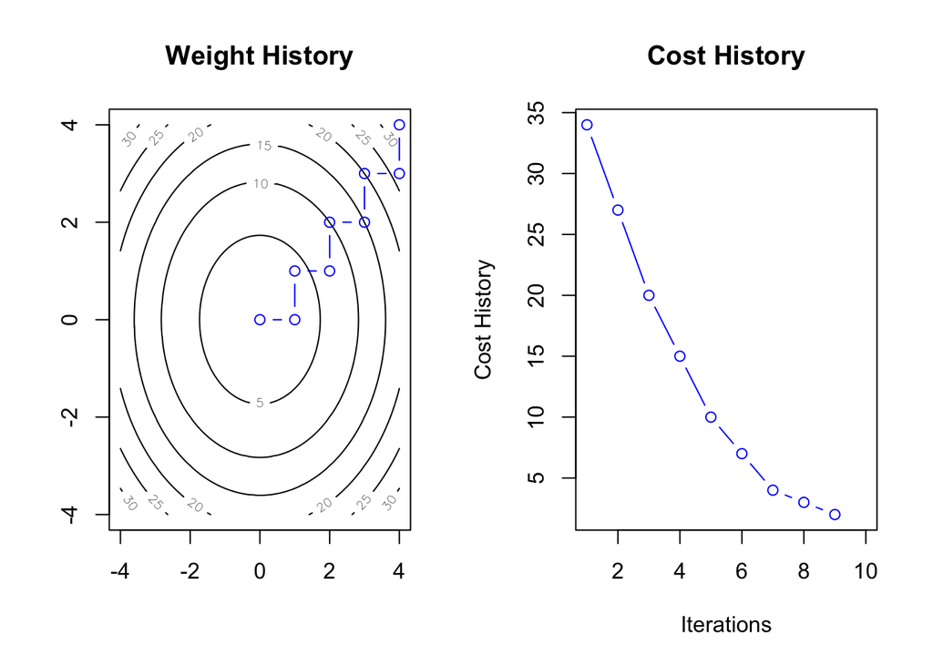

```r
g<- function(w1,w2) w1^2+w2^2+2


v <- coordinate_search(g, w0 = c(4,4))


xgrid <- ygrid<- seq(-4, 4, 0.1)
g_out <- outer(xgrid, ygrid, FUN = g)
par(mfrow=c(1,2))
contour(x= xgrid, y=ygrid, z = g_out,main = "Weight History")
points(v[[1]][,1], v[[1]][,2],type = "b", col="blue")

plot(x = 1:10, y = v[[2]][1:10], type = "b", col = "blue", xlab = "Iterations", ylab = "Cost History", main = "Cost History")
```

**c**

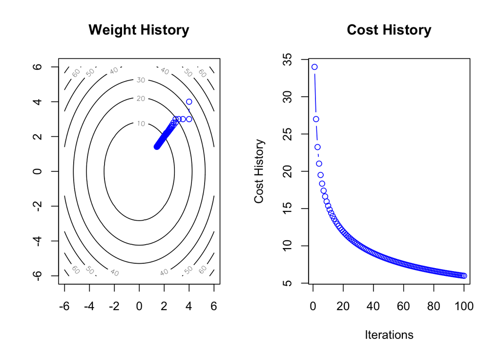

```r
v1 <- coordinate_search(g,alpha_choice = "diminishing", w0 = c(4,4))

xgrid <- ygrid<- seq(-6, 6, 0.1)
g_out <- outer(xgrid, ygrid, FUN = g)
par(mfrow=c(1,2))
contour(x= xgrid, y=ygrid, z = g_out,main = "Weight History")
points(v1[[1]][,1], v1[[1]][,2],type = "b", col="blue")

plot(x = 1:100, y = v1[[2]][1:100], type = "b", col = "blue", xlab = "Iterations", ylab = "Cost History", main = "Cost History")
```

**d**

I was able to find the global minimum by choosing the starting point as w0 = c(-5,5) and a step length of 0.1, and max_its to be 150. The global mininum of the cost function is 0.

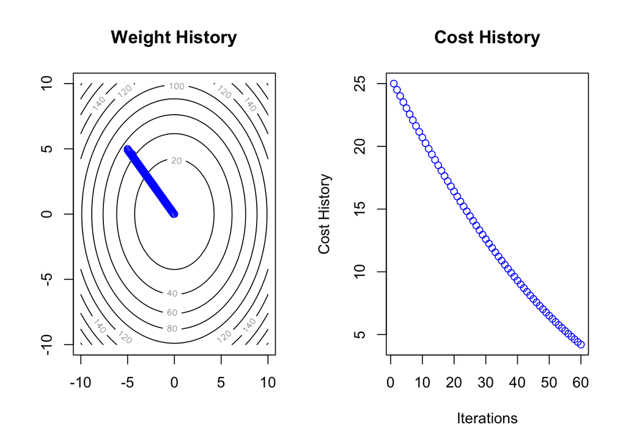

```r
g1<- function(w1,w2) 0.26*((w1)^2+(w2)^2) - 0.48*w1*w2

v2 <- coordinate_search(g1,alpha_choice = 0.1,max_its = 150, w0 = c(-5,5))

xgrid <- ygrid<- seq(-10, 10, 0.1)
g_out <- outer(xgrid, ygrid, FUN = g)
par(mfrow=c(1,2))
contour(x= xgrid, y=ygrid, z = g_out,main = "Weight History")
points(v2[[1]][,1], v2[[1]][,2],type = "b", col="blue")

plot(x = 1:60, y = v2[[2]][1:60], type = "b", col = "blue", xlab = "Iterations", ylab = "Cost History", main = "Cost History")
```

```r
# Global minimum

v2[[2]][dim(v2[[1]])[1]]
```

```
## [1] 1.054639e-30
```

```r
# As we can see the global minimum will be achieve with
for (i in v2[[1]][dim(v2[[1]])[1],]){
  print(all.equal(i,0))
}
```

```
## [1] TRUE
## [1] TRUE
```

**2**

**a**

pseudo-code:

Input: # g: A cost function: # alpha choice: If it is “diminishing”, execute random search with diminishing # steplength. If it is a numerical value, let it be the fixed steplength (default: 1). # max its: The maximum number of iteration (default: 100) # w0: An initial point # tol: The tolerance for the stop criteria (default: 10−5) # # output: list object # weight history: A n × 2 matrix for weight history # cost history: A vector for corresponding cost function history

w1<- w0[1] w2<- w0[2] weight_history_w1<- w1 weight_history_w2<- w2 cost_history<- g(w1,w2) current_value <- g(w1, w2)

For each odd iteration,

we want to try the vertical directions (North, South) times learning rate (step length) and this gives the distance) Among the two new coordinates, evaluate them by plugging into g if the new cost and current cost is too small, terminate the algorithm find the one gives the least cost and comparing to the current cost, replace the current cost if it is smaller than the current cost and also save the coordinates so we can update the current coordinate and save the new coordinates into weight_history save the cost history

For each even iteration,

we want to try the horizontal directions (West, East) times learning rate (step length) and this gives the distance) Among the two new coordinates, evaluate them by plugging into g if the new cost and current cost is too small, terminate the algorithm find the one gives the least cost and comparing to the current cost, replace the current cost if it is smaller than the current cost and also save the coordinates so we can update the current coordinate and save the new coordinates into weight_history save the cost history

return cost history and weight_history

```r
coordinate_descent_0<- function(g, alpha_choice = 1, max_its = 100, w0, tol = 10^-5){
  #Input:
  # g: A cost function:
  # alpha choice: If it is “diminishing”, execute random search with diminishing
  # steplength. If it is a numerical value, let it be the fixed steplength (default: 1).
  # max its: The maximum number of iteration (default: 100)
  #
  # w0: An initial point
  # tol: The tolerance for the stop criteria (default: 10−5)
  #
  # output: list object
  # weight history: A n × 2 matrix for weight history
  # cost history: A vector for corresponding cost function history

  w1<- w0[1]
  w2<- w0[2]
  weight_history_w1<- w1
  weight_history_w2<- w2
  cost_history<- g(w1,w2)
  current_value <- g(w1, w2)

  if(alpha_choice == "diminishing"){
    alpha_choice<- 1/(1:max_its)
  }else{
    alpha_choice<- rep(alpha_choice, max_its)
  }

  for(i in 1:max_its){
    if (i%%2 == 0){
       # evaluating g function two directions
    wa <- w1-alpha_choice[i]
    wb <- w1+alpha_choice[i]
    wab<- c(wa,wb)
    v1 = c(g(wa, w2), g(wb, w2))
    if(abs(current_value - v1[which.min(v1)]) <= tol) break
    if(v1[which.min(v1)] < current_value){
      w1 = wab[which.min(v1)]
      current_value = g(w1,w2)
      weight_history_w1<- c(weight_history_w1, w1)
      cost_history<- c(cost_history, g(w1, w2))
    }
    }

    else{
          # evaluating g function two directions
     wc <- w2-alpha_choice[i]
     wd <- w2+alpha_choice[i]
     wcd <-c(wc,wd)
     v2 = c(g(w1, wc), g(w1, wd))
     if(abs(current_value - v2[which.min(v2)]) <= tol) break
     if(v2[which.min(v2)] < current_value){
      w2 = wcd[which.min(v2)]
      current_value = g(w1,w2)
      weight_history_w2<- c(weight_history_w2, w2)
      cost_history<- c(cost_history, g(w1, w2))
    }
    }

  }

  weight_history = cbind(weight_history_w1, weight_history_w2)
  output <- list(weight_history, cost_history)
  output

  }
```

**b**

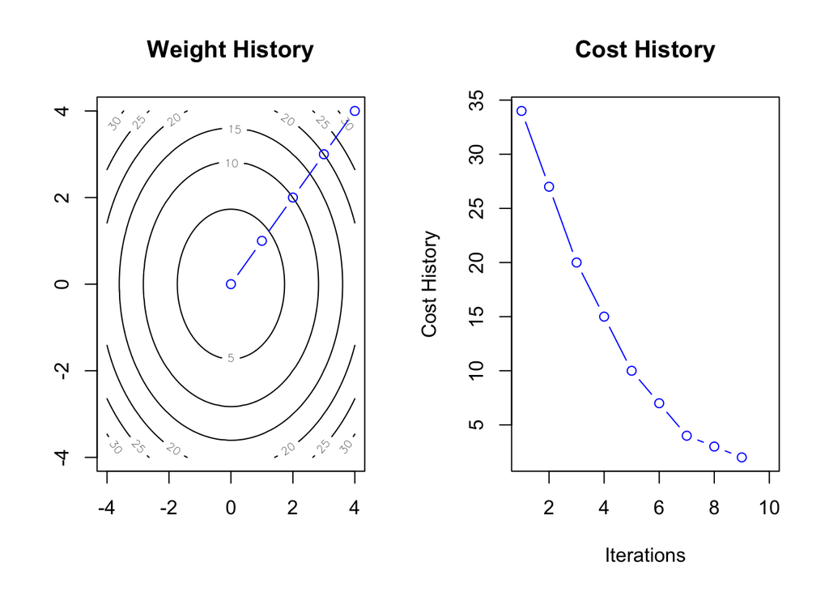

```r
g<- function(w1,w2) w1^2+w2^2+2

v <- coordinate_descent_0(g, w0 = c(4,4))


xgrid <- ygrid<- seq(-4, 4, 0.1)
g_out <- outer(xgrid, ygrid, FUN = g)
par(mfrow=c(1,2))
contour(x= xgrid, y=ygrid, z = g_out,main = "Weight History")
points(v[[1]][,1], v[[1]][,2],type = "b", col="blue")

plot(x = 1:10, y = v[[2]][1:10], type = "b", col = "blue", xlab = "Iterations", ylab = "Cost History", main = "Cost History")
```

**c**

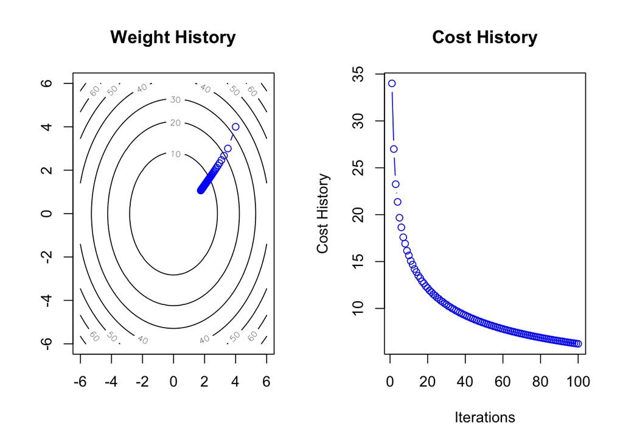

```r
v1 <- coordinate_descent_0(g,alpha_choice = "diminishing", w0 = c(4,4))

xgrid <- ygrid<- seq(-6, 6, 0.1)
g_out <- outer(xgrid, ygrid, FUN = g)
par(mfrow=c(1,2))
contour(x= xgrid, y=ygrid, z = g_out,main = "Weight History")
points(v1[[1]][,1], v1[[1]][,2],type = "b", col="blue")

plot(x = 1:100, y = v1[[2]][1:100], type = "b", col = "blue", xlab = "Iterations", ylab = "Cost History", main = "Cost History")
```

**d**

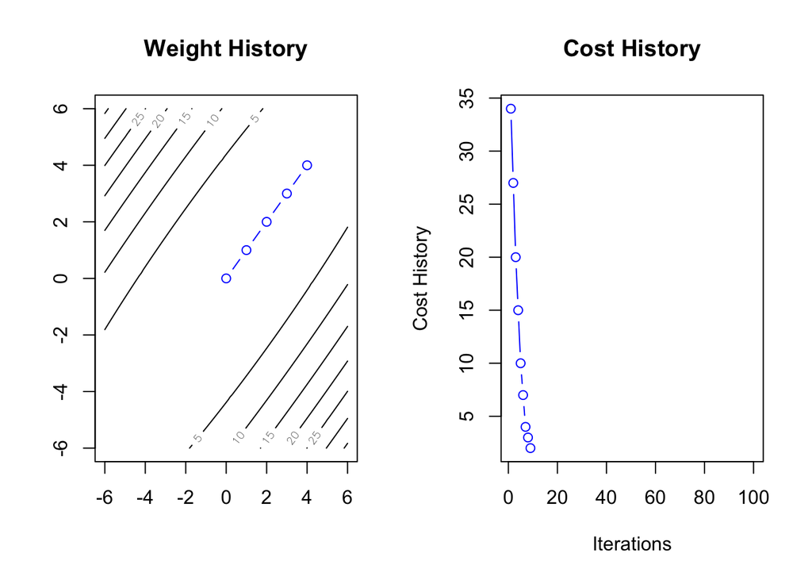

```r
g1<- function(w1,w2) 0.26*((w1)^2+(w2)^2) - 0.48*w1*w2

xgrid <- ygrid<- seq(-6, 6, 0.1)
g_out <- outer(xgrid, ygrid, FUN = g1)
par(mfrow=c(1,2))
contour(x= xgrid, y=ygrid, z = g_out,main = "Weight History")

v1 <- coordinate_descent_0(g,alpha_choice = 1, w0 = c(4,4),max_its = 5000)
points(v1[[1]][,1], v1[[1]][,2],type = "b", col="blue")

plot(x = 1:100, y = v1[[2]][1:100], type = "b", col = "blue", xlab = "Iterations", ylab = "Cost History", main = "Cost History")
```

**3**

**a**

**b**

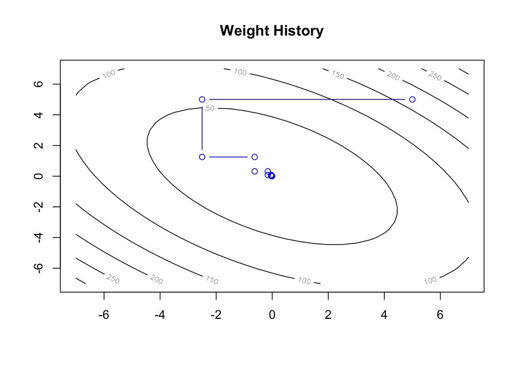

```r
g<- function(w1, w2) 2*w1^2+2*w2^2+2*w1*w2+20

w0<- c(5,5)
tol<- 10^-4
max_its<- 100
alpha_choice<- 1

  w1<- w0[1]
  w2<- w0[2]
  weight_history_w1<- w1
  weight_history_w2<- w2


for (i in 1:max_its){
  current_value = g(w1,w2)
  if (i%%2 == 1){

    New_w1<- alpha_choice*(-1/2*w2)# take Derivative with respect to w1 and solve w1 by setting to 0
    if (abs((g(New_w1,w2) - current_value)) < tol) break
    if (g(New_w1,w2) < current_value ){
      w1 = New_w1
      weight_history_w1 = c( weight_history_w1, w1)
      weight_history_w2 = c( weight_history_w2, w2)
    }
  }else{
    New_w2<- alpha_choice*(-1/2*w1) # take Derivative with respect to w1 and solve w1 by setting to 0
    if (abs((g(w1,New_w2) - current_value)) < tol) break
    if (g(w1,New_w2) < current_value ){
      w2 = New_w2
      weight_history_w1 = c( weight_history_w1, w1)
      weight_history_w2 = c( weight_history_w2, w2)
    }
  }

}

weight_history = rbind(weight_history_w1,weight_history_w2)

ygrid <- seq(-7, 7, 0.5)
xgrid<- seq(-7, 7, 0.5)
g_out <- outer(xgrid, ygrid, FUN = g)
contour( x= xgrid, y=ygrid, z = g_out,main = "Weight History")
points(weight_history[1,], weight_history[2,],type = "b", col="blue")
```

**c**

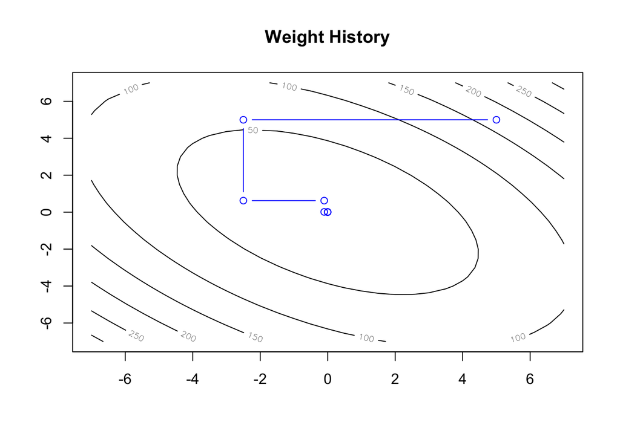

[figure not shown]

Question 4 a and b

```r
g<- function(w1, w2) 2*w1^2+2*w2^2+2*w1*w2+20

w0<- c(5,5)
tol<- 10^-4
max_its<- 100
# steplength diminishing rule.
alpha_choice<- 1/(1:max_its)

  w1<- w0[1]
  w2<- w0[2]
  weight_history_w1<- w1
  weight_history_w2<- w2


for (i in 1:max_its){
  current_value = g(w1,w2)
  if (i%%2 == 1){

    New_w1<- alpha_choice[i]*(-1/2*w2)# take Derivative with respect to w1 and solve w1 by setting to 0
    if (abs((g(New_w1,w2) - current_value)) < tol) break
    if (g(New_w1,w2) < current_value ){
      w1 = New_w1
      weight_history_w1 = c( weight_history_w1, w1)
      weight_history_w2 = c( weight_history_w2, w2)
    }
  }else{
    New_w2<- alpha_choice[i]*(-1/2*w1) # take Derivative with respect to w1 and solve w1 by setting to 0
    if (abs((g(w1,New_w2) - current_value)) < tol) break
    if (g(w1,New_w2) < current_value ){
      w2 = New_w2
      weight_history_w1 = c( weight_history_w1, w1)
      weight_history_w2 = c( weight_history_w2, w2)
    }
  }

}

weight_history = rbind(weight_history_w1,weight_history_w2)

ygrid <- seq(-7, 7, 0.5)
xgrid<- seq(-7, 7, 0.5)
g_out <- outer(xgrid, ygrid, FUN = g)
contour( x= xgrid, y=ygrid, z = g_out,main = "Weight History")
points(weight_history[1,], weight_history[2,],type = "b", col="blue")
```

**5**

**a**

pseudo-code:

Input: # g: A cost function: # alpha choice: If it is “diminishing”, execute random search with diminishing # steplength. If it is a numerical value, let it be the fixed steplength (default: 1). # max its: The maximum number of iteration (default: 100) # w0: An initial point # tol: The tolerance for the stop criteria (default: 10−5) # # output: list object # weight history: A n × 2 matrix for weight history # cost history: A vector for corresponding cost function history

If the input is a vector (2 variables input) For each iteration, w1_new = w1 - alpha_choice[i]*g_prime(w1 = w1)[1] w2_new = w2 - alpha_choice[i]*g_prime(w2 = w2)[2]

if the new w1 and w2, give us a smaller cost than the current cost. Update the current best weights, w1 and w2. Save the coordinates into weight_history, update the new cost and save the cost into cost history.

else, (1 variable input) For each iteration, w0_new = w0 - alpha_choice[i]*g_prime(w0) if the new w0 give us a smaller cost than the current cost. Update the current best weights, w0. Save the coordinates into weight_history, update the new cost and save the cost into cost history.

return cost history and weight_history

```r
gd <- function(g,g_prime, alpha_choice = 1, max_its = 100, w0, tol = 10^-5){
  #Input:
  # g: A cost function:
  # alpha choice: If it is “diminishing”, execute random search with diminishing
  # steplength. If it is a numerical value, let it be the fixed steplength (default: 1).
  # max its: The maximum number of iteration (default: 100)
  #
  # w0: An initial point
  # tol: The tolerance for the stop criteria (default: 10−5)
  #
  # output: list object
  # weight history: A n × 2 matrix for weight history
  # cost history: A vector for corresponding cost function history


  if(alpha_choice == "diminishing"){
    alpha_choice<- 1/(1:max_its)
  }else{
    alpha_choice<- rep(alpha_choice, max_its)
  }

if (length(w0) == 2){


w1<- w0[1]
w2<- w0[2]
weight_history_w1<- w1
weight_history_w2<- w2
cost_history<- g(w1,w2)
current_value <- g(w1, w2)


 for(i in 1:max_its){
   w1_new = w1 - alpha_choice[i]*g_prime(w1 = w1)[1]
   w2_new = w2 - alpha_choice[i]*g_prime(w2 = w2)[2]
   if(abs(g(w1_new,w2_new) -current_value ) <= tol) break
   if (g(w1_new,w2_new) < current_value){
     w1 = w1_new
     w2 = w2_new
     weight_history_w1 = c(weight_history_w1,w1)
     weight_history_w2 = c(weight_history_w2,w2)
     current_value = g(w1,w2)
     cost_history = c(cost_history,current_value)

   }



 }
    weight_history = cbind(weight_history_w1, weight_history_w2)

}else{


weight_history <- w0
cost_history<- g(w0)
current_value <- g(w0)


 for(i in 1:max_its){
   w0_new = w0 - alpha_choice[i]*g_prime(w0)
   if(abs(g(w0_new) -current_value) <= tol) break
   if (g(w0_new) < current_value){
     w0 = w0_new
     weight_history = c(weight_history,w0)
     current_value = g(w0)
     cost_history = c(cost_history,current_value)
   }

  }

}

  output <- list(weight_history, cost_history)
  return(output)

}
```

**b**

As we can see from the plot, when the step length is 1, we can find the global minimum the fastest (with the least number of iterations). If we are doing the same numbers of iterations, with a step length of 0.1 and 0.01, our algorithm cannot find the global minimum.

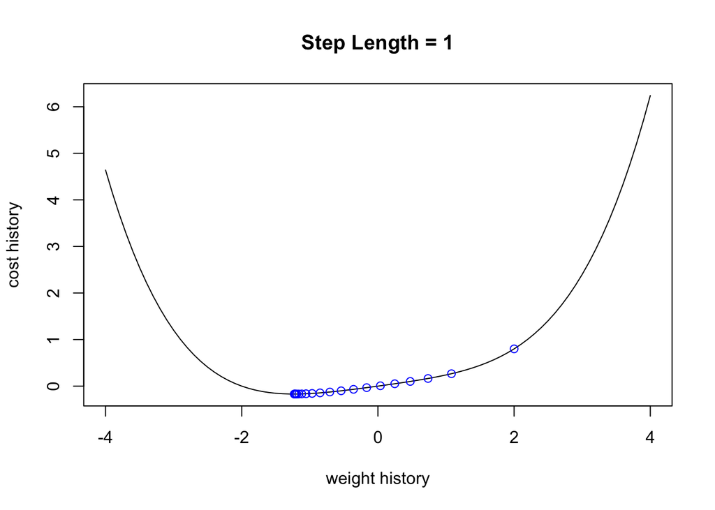

```r
g<- function(w){
  1/50*(w^4+w^2+10*w)
}
g_prime<- function(w){
  1/50*(4*w^3+2*w+10)
}

xgrid <- seq(-4, 4, 0.1)

v <- gd(g, g_prime, w0 = 2, alpha_choice = 1)

plot(xgrid, g(xgrid), type = "l", main = "Step Length = 1",ylab = "cost history", xlab = "weight history")
points(v[[1]], v[[2]], col="blue")
```

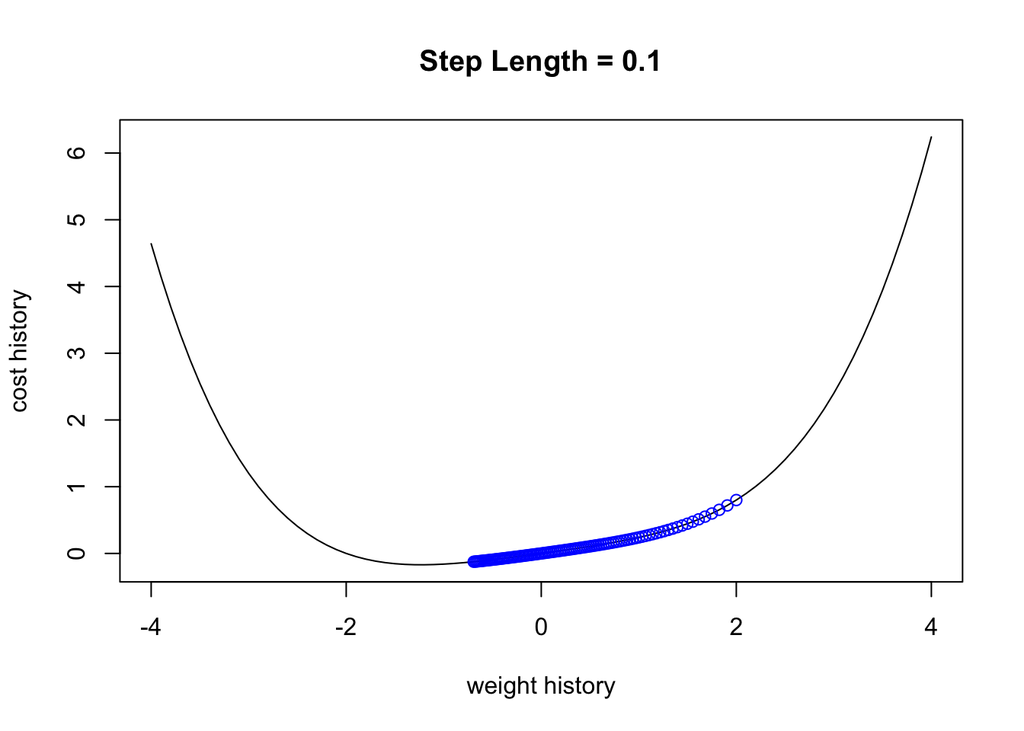

```r
g<- function(w){
  1/50*(w^4+w^2+10*w)
}
g_prime<- function(w){
  1/50*(4*w^3+2*w+10)
}

xgrid <- seq(-4, 4, 0.1)

v_01 <- gd(g, g_prime, w0 = 2, alpha_choice = 0.1)

plot(xgrid, g(xgrid), type = "l", main = "Step Length = 0.1",ylab = "cost history", xlab = "weight history")
points(v_01[[1]], v_01[[2]], col="blue")
```

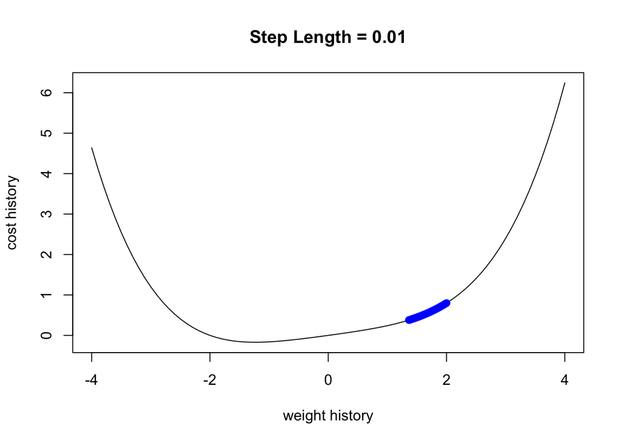

```r
g<- function(w){
  1/50*(w^4+w^2+10*w)
}
g_prime<- function(w){
  1/50*(4*w^3+2*w+10)
}

xgrid <- seq(-4, 4, 0.1)

v_001 <- gd(g, g_prime, w0 = 2, alpha_choice = 0.01)

plot(xgrid, g(xgrid), type = "l", main = "Step Length = 0.01",ylab = "cost history", xlab = "weight history")
points(v_001[[1]], v_001[[2]], col="blue")
```

**c**

With a diminishing steplength rule, it will take many iterations to find the global minimum.

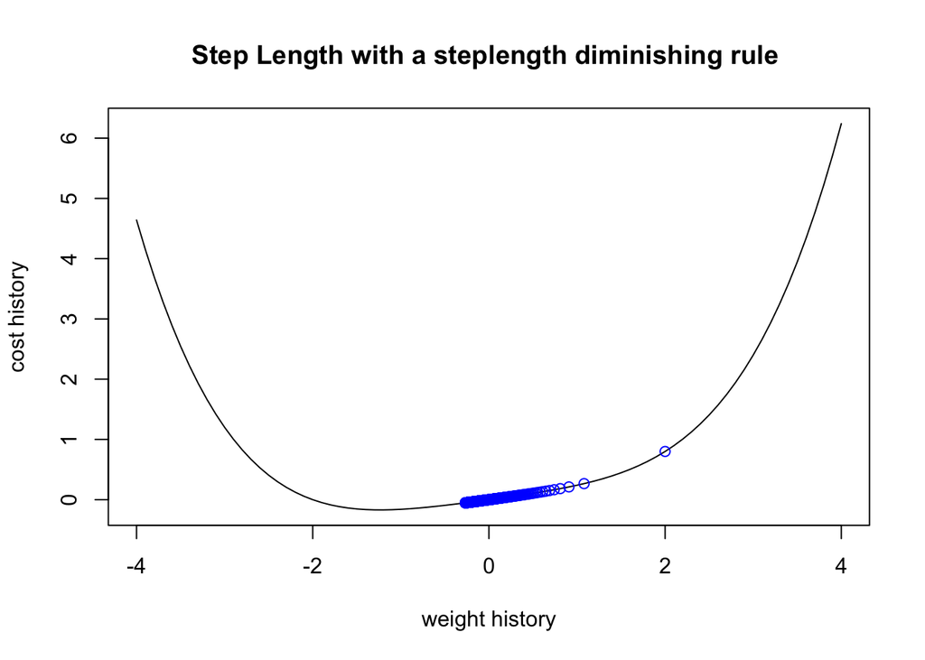

```r
g<- function(w){
  1/50*(w^4+w^2+10*w)
}
g_prime<- function(w){
  1/50*(4*w^3+2*w+10)
}

xgrid <- seq(-4, 4, 0.1)

v_d <- gd(g, g_prime, w0 = 2, alpha_choice = "diminishing",max_its = 500)

plot(xgrid, g(xgrid), type = "l", main = "Step Length with a steplength diminishing rule ",ylab = "cost history", xlab = "weight history")
points(v_d[[1]], v_d[[2]], col="blue")
```

**d**

for g function. The minimum is 4.

```r
g<- function(w1,w2) w1^2+w2^2-2*w1-2*w2+6


g_prime<- function(w1 = 0,w2 = 0){

  a <- 2*w1-2
  b <- 2*w2-2
  c(a,b)
}

xgrid <- ygrid <- seq(-4, 4, 0.1)
g_out <- outer(xgrid, ygrid, FUN = g)

contour( x= xgrid, y=ygrid, z = g_out, main = "Weight History Plot")


v <- gd(g, g_prime, w0 = c(2,2), alpha_choice = 0.1)
v
```

```
## [[1]]
##       weight_history_w1 weight_history_w2
##  [1,]          2.000000          2.000000
##  [2,]          1.800000          1.800000
##  [3,]          1.640000          1.640000
##  [4,]          1.512000          1.512000
##  [5,]          1.409600          1.409600
##  [6,]          1.327680          1.327680
##  [7,]          1.262144          1.262144
##  [8,]          1.209715          1.209715
##  [9,]          1.167772          1.167772
## [10,]          1.134218          1.134218
## [11,]          1.107374          1.107374
## [12,]          1.085899          1.085899
## [13,]          1.068719          1.068719
```

[output cut: 20 more lines]

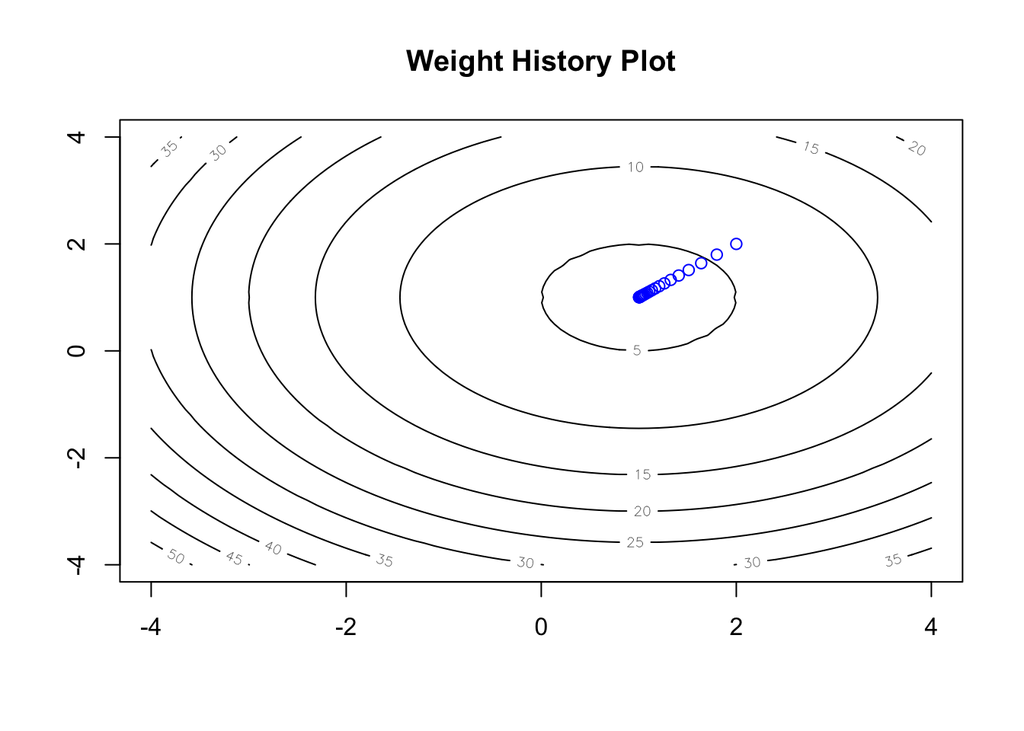

```r
points(v[[1]][,1], v[[1]][,2],type = "b", col="blue")
```

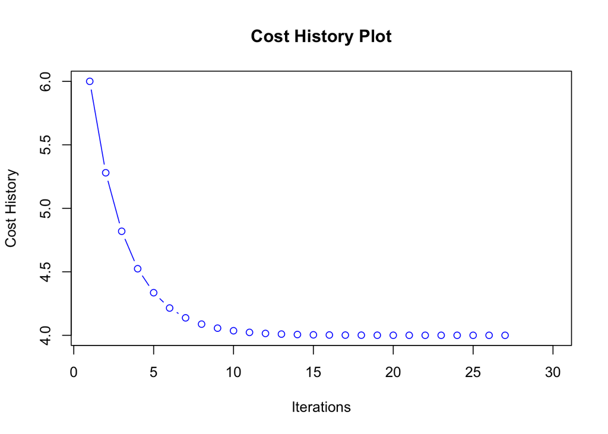

```r
plot(x = 1:30, y = v[[2]][1:30], type = "b", col = "blue", xlab = "Iterations", ylab = "Cost History", main = "Cost History Plot")
```

```r
G<- function(w1,w2) ((w1^4+w2^4)/4)-((w1^3+w2^3)/3)-x^2-y^2+4


G_prime<- function(w1 = 0,w2 = 0){
  a <- w1^3 - w1^2 - 2*w1
  b <- w2^3 - w2^2 - 2*w2
  c(a,b)
}

xgrid <- ygrid <- seq(-4, 4, 0.1)
g_out <- outer(xgrid, ygrid, FUN = g)

contour( x= xgrid, y=ygrid, z = g_out, main = "Weight History Plot")


v <- gd(g, g_prime, w0 = c(-2,2), alpha_choice = 0.1,max_its = 1000, tol = 10^-10)
v
```

```
## [[1]]
##       weight_history_w1 weight_history_w2
##  [1,]        -2.0000000          2.000000
##  [2,]        -1.4000000          1.800000
##  [3,]        -0.9200000          1.640000
##  [4,]        -0.5360000          1.512000
##  [5,]        -0.2288000          1.409600
##  [6,]         0.0169600          1.327680
##  [7,]         0.2135680          1.262144
##  [8,]         0.3708544          1.209715
##  [9,]         0.4966835          1.167772
## [10,]         0.5973468          1.134218
## [11,]         0.6778775          1.107374
## [12,]         0.7423020          1.085899
## [13,]         0.7938416          1.068719
```

[output cut: 53 more lines]

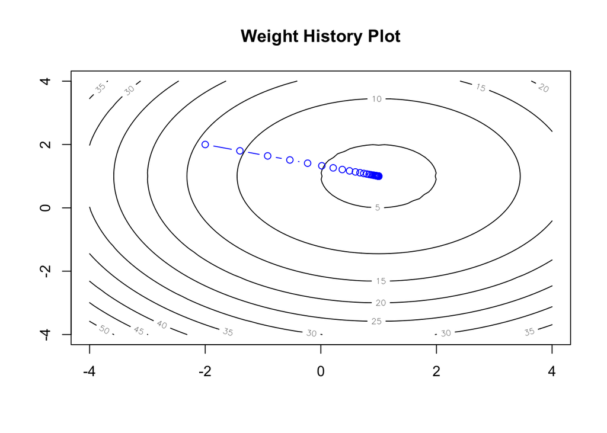

```r
points(v[[1]][,1], v[[1]][,2],type = "b", col="blue")
```

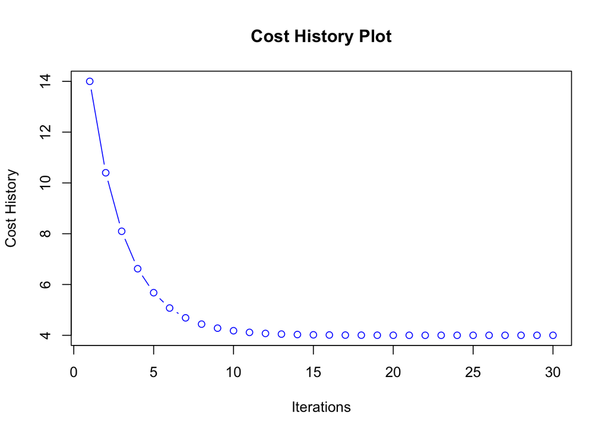

```r
plot(x = 1:30, y = v[[2]][1:30], type = "b", col = "blue", xlab = "Iterations", ylab = "Cost History", main = "Cost History Plot")
```

**6**

**a**

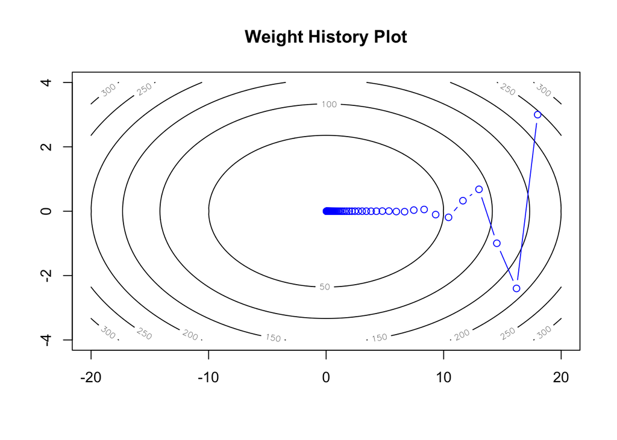

```r
g<- function(w1,w2) 0.5 * w1^2 + 9 * w2^2


w1 = 18
w2 = 3
tol = 10^-4

max_its = 100


alpha_choice = 0.1

d<- function(w1, w2, beta, d_p){
  New_w1 <- w1 # derivative
  New_w2 <- 18*w2
  return((beta * d_p) + (1-beta) * -matrix(c(New_w1,New_w2), nrow = 2))
}

cv = g(w1,w2)
d_p = matrix(c(-18,-54),nrow = 2)

weight_history_w1 = w1
weight_history_w2 = w2
cost_history = cv

for (i in 1:max_its){

  a = d(w1,w2,0.3,d_p)[1]
  b = d(w1,w2,0.3,d_p)[2]

  w1_candidate = w1 + alpha_choice * a



  w2_candidate = w2 + alpha_choice * b

   d_p =matrix(c(a,b),nrow = 2)



  if(abs(g(w1_candidate,w2_candidate) -cv) <= tol) break
  if(g(w1_candidate,w2_candidate)<cv){


     w1 = w1_candidate
     w2 = w2_candidate
     weight_history_w1 = c(weight_history_w1,w1)
     weight_history_w2 = c(weight_history_w2,w2)
     cv = g(w1,w2)
     cost_history = c(cost_history,cv)}



  }



xgrid <- seq(-20, 20, 0.1)
ygrid <- seq(-4, 4, 0.1)
g_out <- outer(xgrid, ygrid, FUN = g)

contour( x= xgrid, y=ygrid, z = g_out, main = "Weight History Plot")

points(weight_history_w1, weight_history_w2,type = "b", col="blue")
```

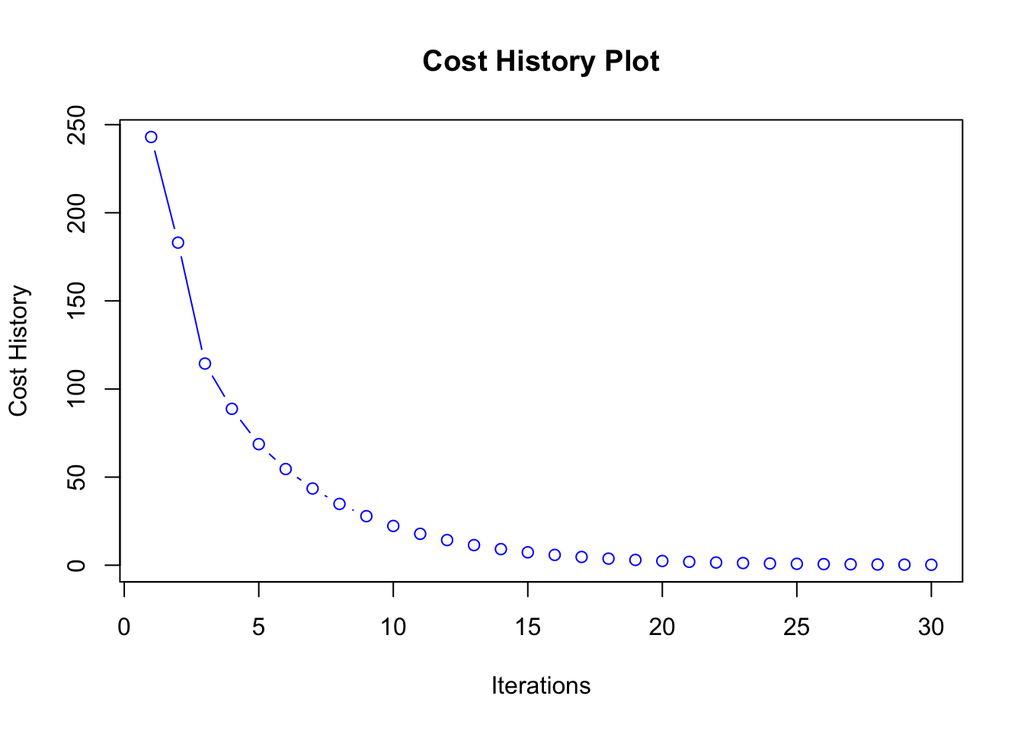

```r
plot(x = 1:30, y = cost_history[1:30], type = "b", col = "blue", xlab = "Iterations", ylab = "Cost History", main = "Cost History Plot")
```

**b**

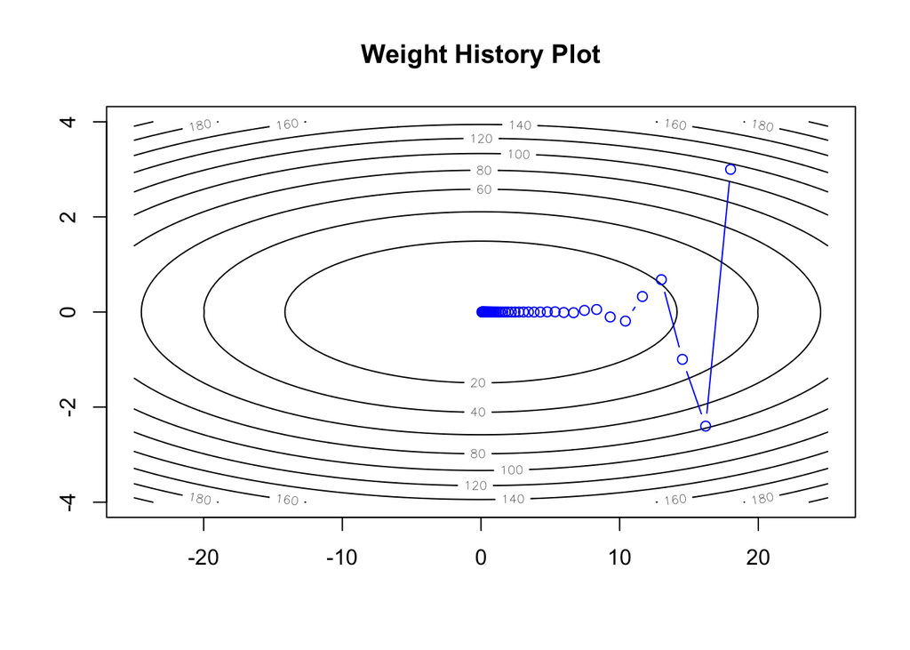

```r
g<- function(w1,w2) 0.1 * w1^2 + 9 * w2^2


w1 = 18
w2 = 3
tol = 10^-4

max_its = 100


alpha_choice = 0.1

d<- function(w1, w2, beta, d_p){
  New_w1 <- w1 # derivative
  New_w2 <- 18*w2
  return((beta * d_p) + (1-beta) * -matrix(c(New_w1,New_w2), nrow = 2))
}

cv = g(w1,w2)
d_p = matrix(c(-18,-54),nrow = 2)

weight_history_w1 = w1
weight_history_w2 = w2
cost_history = cv

for (i in 1:max_its){

  a = d(w1,w2,0.3,d_p)[1]
  b = d(w1,w2,0.3,d_p)[2]

  w1_candidate = w1 + alpha_choice * a

  w2_candidate = w2 + alpha_choice * b

   d_p =matrix(c(a,b),nrow = 2)

  if(abs(g(w1_candidate,w2_candidate) -cv) <= tol) break
  if(g(w1_candidate,w2_candidate)<cv){

     w1 = w1_candidate
     w2 = w2_candidate
     weight_history_w1 = c(weight_history_w1,w1)
     weight_history_w2 = c(weight_history_w2,w2)
     cv = g(w1,w2)
     cost_history = c(cost_history,cv)}

  }

ygrid <- seq(-4, 4, 0.1)
xgrid<- seq(-25, 25, 0.1)

g_out <- outer(xgrid, ygrid, FUN = g)

contour( x= xgrid, y=ygrid, z = g_out, main = "Weight History Plot")

points(weight_history_w1, weight_history_w2,type = "b", col="blue")
```

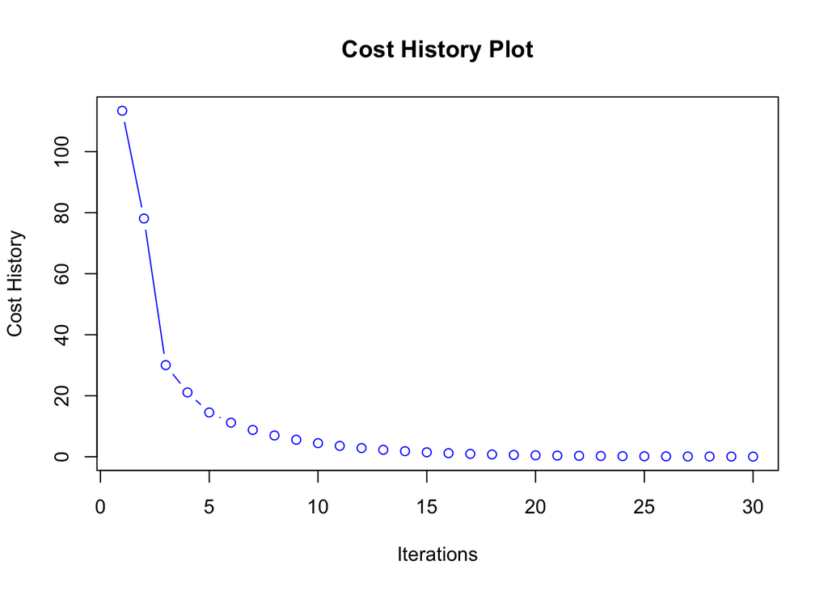

```r
plot(x = 1:30, y = cost_history[1:30], type = "b", col = "blue", xlab = "Iterations", ylab = "Cost History", main = "Cost History Plot")
```